# Week 4 homework-MSDS6306

Karen Clark

May 29, 2016

The Central Limit Theorem (CLT) states that, given certain conditions you can expect the arthimetic mean of a large number of iterations of independent variables and well-definted expected values and variances, will be fairly normally distributed regardless of the underlying distribution.

This assignment was to prove the theorem by taking two samples of differing sample sizes to test this. Basically the CLT states that as the number of samples increase for any given population, the distrbution of the averages for those samples will move closer to a normally distributed.

To test the CLT theorem I have two random datasets. One has a sample size of 10 and the other is a sample size of 75. Each data set was created using the bootstrap methodolgy of looping to replicate the random sampling.

Below are the histograms:

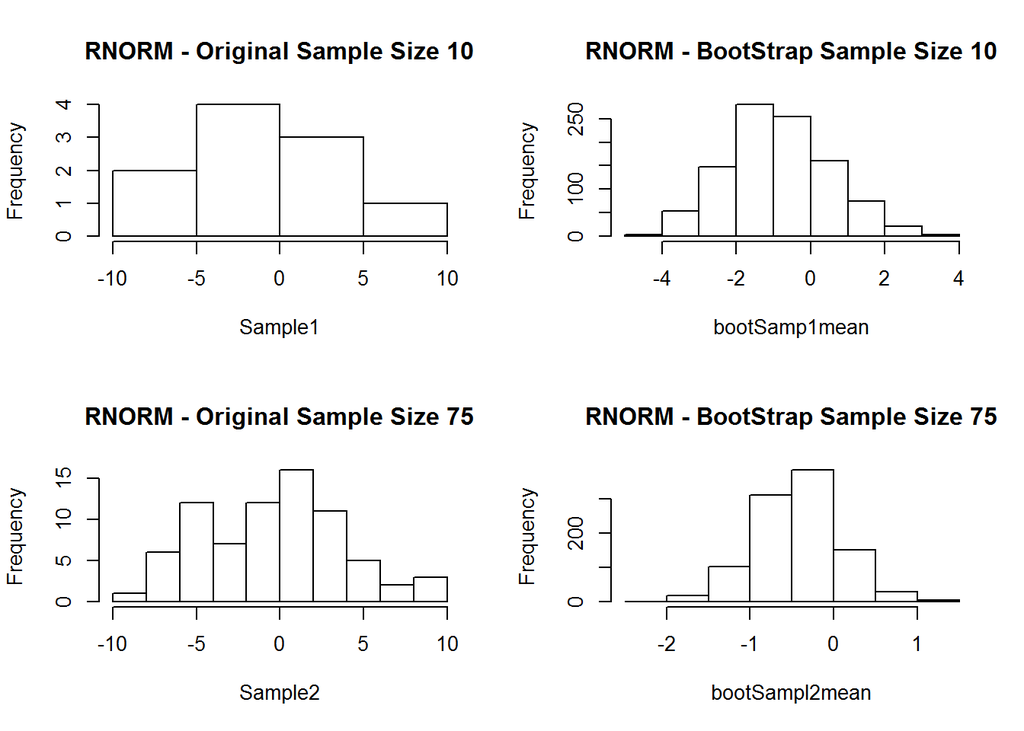

The original datasets seemed do not appear to be normally distributed and are hard to evaluate. When the datasets are then processed through the bootstrap methodolgy for a 1000 iterations, and the averages are evaluated from these samples, it does appearthat the datasets are distributed normally.

[figure not shown]